# Project: TMDb Movies Data Analysis

### Data Cleaning

> In This Section: We will remove the unnecessary data or columns from our data to make the exploration more easy.
> 1. Convert release_date column to date format
> 2. Remove the some columns and put the new data into new data frame to make the data more readable which are:
>    - id
>    - imdb_id
>    - homepage
>    - tagline
>    - keywords
>    - overview
>    - production_companies
> 3. Organize the columns of the data
> 4. Remove duplicated rows in the new data
> 5. Replacing all zeros in budget and revenue columns to NaN and then remove all NaNs Values
1. Convert release_date column type

```python
df_original_data.release_date=pd.to_datetime(df_original_data['release_date'])
df_original_data.info()
```

```
<class 'pandas.core.frame.DataFrame'>
RangeIndex: 10866 entries, 0 to 10865
Data columns (total 21 columns):
id                      10866 non-null int64
imdb_id                 10856 non-null object
popularity              10866 non-null float64
budget                  10866 non-null int64
revenue                 10866 non-null int64
original_title          10866 non-null object
cast                    10790 non-null object
homepage                2936 non-null object
director                10822 non-null object
tagline                 8042 non-null object
keywords                9373 non-null object
overview                10862 non-null object
runtime                 10866 non-null int64
genres                  10843 non-null object
production_companies    9836 non-null object
release_date            10866 non-null datetime64[ns]
vote_count              10866 non-null int64
vote_average            10866 non-null float64
release_year            10866 non-null int64
budget_adj              10866 non-null float64
revenue_adj             10866 non-null float64
dtypes: datetime64[ns](1), float64(4), int64(6), object(10)
memory usage: 1.7+ MB
```

1. Remove the unuseful columns which are:
   - id
   - imdb_id
   - homepage
   - tagline
   - keywords
   - overview
   - production_companies

```python
deleted_columns=['id','imdb_id','homepage','tagline','keywords','overview','production_companies']
df_new_data= df_original_data.drop(deleted_columns,axis=1)
df_new_data.head()
```

|  | popularity | budget | revenue | original_title | cast | director | runtime | genres | release_date | vote_count | vote_average | release_year | budget_adj | revenue_adj |
| --- | --- | --- | --- | --- | --- | --- | --- | --- | --- | --- | --- | --- | --- | --- |
| 0 | 32.985763 | 150000000 | 1513528810 | Jurassic World | Chris Pratt\|Bryce Dallas Howard\|Irrfan Khan\|Vi... | Colin Trevorrow | 124 | Action\|Adventure\|Science Fiction\|Thriller | 2015-06-09 | 5562 | 6.5 | 2015 | 1.379999e+08 | 1.392446e+09 |
| 1 | 28.419936 | 150000000 | 378436354 | Mad Max: Fury Road | Tom Hardy\|Charlize Theron\|Hugh Keays-Byrne\|Nic... | George Miller | 120 | Action\|Adventure\|Science Fiction\|Thriller | 2015-05-13 | 6185 | 7.1 | 2015 | 1.379999e+08 | 3.481613e+08 |
| 2 | 13.112507 | 110000000 | 295238201 | Insurgent | Shailene Woodley\|Theo James\|Kate Winslet\|Ansel... | Robert Schwentke | 119 | Adventure\|Science Fiction\|Thriller | 2015-03-18 | 2480 | 6.3 | 2015 | 1.012000e+08 | 2.716190e+08 |
| 3 | 11.173104 | 200000000 | 2068178225 | Star Wars: The Force Awakens | Harrison Ford\|Mark Hamill\|Carrie Fisher\|Adam D... | J.J. Abrams | 136 | Action\|Adventure\|Science Fiction\|Fantasy | 2015-12-15 | 5292 | 7.5 | 2015 | 1.839999e+08 | 1.902723e+09 |
| 4 | 9.335014 | 190000000 | 1506249360 | Furious 7 | Vin Diesel\|Paul Walker\|Jason Statham\|Michelle ... | James Wan | 137 | Action\|Crime\|Thriller | 2015-04-01 | 2947 | 7.3 | 2015 | 1.747999e+08 | 1.385749e+09 |

Reordering the columns position for better reading

```python
columns=['original_title','director','cast','release_date','release_year','genres','runtime','popularity','vote_count','vote_average','budget_adj','revenue_adj','budget','revenue']
df_new_data = df_new_data[columns]
df_new_data.head()
```

|  | original_title | director | cast | release_date | release_year | genres | runtime | popularity | vote_count | vote_average | budget_adj | revenue_adj | budget | revenue |
| --- | --- | --- | --- | --- | --- | --- | --- | --- | --- | --- | --- | --- | --- | --- |
| 0 | Jurassic World | Colin Trevorrow | Chris Pratt\|Bryce Dallas Howard\|Irrfan Khan\|Vi... | 2015-06-09 | 2015 | Action\|Adventure\|Science Fiction\|Thriller | 124 | 32.985763 | 5562 | 6.5 | 1.379999e+08 | 1.392446e+09 | 150000000 | 1513528810 |
| 1 | Mad Max: Fury Road | George Miller | Tom Hardy\|Charlize Theron\|Hugh Keays-Byrne\|Nic... | 2015-05-13 | 2015 | Action\|Adventure\|Science Fiction\|Thriller | 120 | 28.419936 | 6185 | 7.1 | 1.379999e+08 | 3.481613e+08 | 150000000 | 378436354 |
| 2 | Insurgent | Robert Schwentke | Shailene Woodley\|Theo James\|Kate Winslet\|Ansel... | 2015-03-18 | 2015 | Adventure\|Science Fiction\|Thriller | 119 | 13.112507 | 2480 | 6.3 | 1.012000e+08 | 2.716190e+08 | 110000000 | 295238201 |
| 3 | Star Wars: The Force Awakens | J.J. Abrams | Harrison Ford\|Mark Hamill\|Carrie Fisher\|Adam D... | 2015-12-15 | 2015 | Action\|Adventure\|Science Fiction\|Fantasy | 136 | 11.173104 | 5292 | 7.5 | 1.839999e+08 | 1.902723e+09 | 200000000 | 2068178225 |
| 4 | Furious 7 | James Wan | Vin Diesel\|Paul Walker\|Jason Statham\|Michelle ... | 2015-04-01 | 2015 | Action\|Crime\|Thriller | 137 | 9.335014 | 2947 | 7.3 | 1.747999e+08 | 1.385749e+09 | 190000000 | 1506249360 |

```python
df_new_data.info()
```

```
<class 'pandas.core.frame.DataFrame'>
RangeIndex: 10866 entries, 0 to 10865
Data columns (total 14 columns):
original_title    10866 non-null object
director          10822 non-null object
cast              10790 non-null object
release_date      10866 non-null datetime64[ns]
release_year      10866 non-null int64
genres            10843 non-null object
runtime           10866 non-null int64
popularity        10866 non-null float64
vote_count        10866 non-null int64
vote_average      10866 non-null float64
budget_adj        10866 non-null float64
revenue_adj       10866 non-null float64
budget            10866 non-null int64
revenue           10866 non-null int64
dtypes: datetime64[ns](1), float64(4), int64(5), object(4)
memory usage: 1.2+ MB
```

1. Drop duplicated rows

```python
# Delete the duplicated rows
df_new_data.drop_duplicates(inplace=True)
```

```python
sum(df_new_data.duplicated())
```

```
0
```

There are some movies with 0 budget or 0 revenue. Those movies will not help us at analysis so, we will delete them because our analysis depends on the revenue and the budget

1. Replacing all zeros in budget and revenue columns to NaN and then remove all NaNs Values

```python
# creating a seperate list of revenue and budget column
df_columns=['budget', 'revenue']

#this will replace all the value from '0' to NAN in the list
df_new_data[df_columns] = df_new_data[df_columns].replace(0, np.NAN)

#Removing all the row which has NaN value in temp_list
df_new_data.dropna(inplace = True)
df_new_data.info()
```

```
<class 'pandas.core.frame.DataFrame'>
Int64Index: 3849 entries, 0 to 10848
Data columns (total 14 columns):
original_title    3849 non-null object
director          3849 non-null object
cast              3849 non-null object
release_date      3849 non-null datetime64[ns]
release_year      3849 non-null int64
genres            3849 non-null object
runtime           3849 non-null int64
popularity        3849 non-null float64
vote_count        3849 non-null int64
vote_average      3849 non-null float64
budget_adj        3849 non-null float64
revenue_adj       3849 non-null float64
budget            3849 non-null float64
revenue           3849 non-null float64
dtypes: datetime64[ns](1), float64(6), int64(3), object(4)
memory usage: 451.1+ KB
```

```python
df_new_data.isnull().sum().sum()
```

```
0
```

Now, We clean our data set

## Exploratory Data Analysis

### Question 1: Which Movie has the higher revenue ?

```python
df_new_data[df_new_data['revenue']==df_new_data['revenue'].max()]
```

|  | original_title | director | cast | release_date | release_year | genres | runtime | popularity | vote_count | vote_average | budget_adj | revenue_adj | budget | revenue |
| --- | --- | --- | --- | --- | --- | --- | --- | --- | --- | --- | --- | --- | --- | --- |
| 1386 | Avatar | James Cameron | Sam Worthington\|Zoe Saldana\|Sigourney Weaver\|S... | 2009-12-10 | 2009 | Action\|Adventure\|Fantasy\|Science Fiction | 162 | 9.432768 | 8458 | 7.1 | 2.408869e+08 | 2.827124e+09 | 237000000.0 | 2.781506e+09 |

### Question 2: Which Movie has the lowest revenue ?

```python
df_new_data[df_new_data['revenue']==df_new_data['revenue'].min()]
```

|  | original_title | director | cast | release_date | release_year | genres | runtime | popularity | vote_count | vote_average | budget_adj | revenue_adj | budget | revenue |
| --- | --- | --- | --- | --- | --- | --- | --- | --- | --- | --- | --- | --- | --- | --- |
| 5067 | Shattered Glass | Billy Ray | Hayden Christensen\|Peter Sarsgaard\|ChloÃ« Sevi... | 2003-11-14 | 2003 | Drama\|History | 94 | 0.462609 | 46 | 6.4 | 7.112116e+06 | 2.370705 | 6000000.0 | 2.0 |
| 8142 | Mallrats | Kevin Smith | Jason Lee\|Jeremy London\|Shannen Doherty\|Claire... | 1995-10-20 | 1995 | Romance\|Comedy | 94 | 0.552091 | 201 | 6.8 | 8.585801e+06 | 2.861934 | 6000000.0 | 2.0 |

### Question 3: Which Movie has the higher budget ?

```python
# Continue to explore the data to address your additional research
#   questions. Add more headers as needed if you have more questions to
#   investigate.
df_new_data[df_new_data['budget']==df_new_data['budget'].max()]
```

|  | original_title | director | cast | release_date | release_year | genres | runtime | popularity | vote_count | vote_average | budget_adj | revenue_adj | budget | revenue |
| --- | --- | --- | --- | --- | --- | --- | --- | --- | --- | --- | --- | --- | --- | --- |
| 2244 | The Warrior's Way | Sngmoo Lee | Kate Bosworth\|Jang Dong-gun\|Geoffrey Rush\|Dann... | 2010-12-02 | 2010 | Adventure\|Fantasy\|Action\|Western\|Thriller | 100 | 0.25054 | 74 | 6.4 | 425000000.0 | 11087569.0 | 425000000.0 | 11087569.0 |

### Question 4: Which Movie has the higher profit and its genre?

```python
df_new_data['profit']=df_new_data.revenue-df_new_data.budget
```

```python
df_new_data.head()
```

|  | original_title | director | cast | release_date | release_year | genres | runtime | popularity | vote_count | vote_average | budget_adj | revenue_adj | budget | revenue | profit |
| --- | --- | --- | --- | --- | --- | --- | --- | --- | --- | --- | --- | --- | --- | --- | --- |
| 0 | Jurassic World | Colin Trevorrow | Chris Pratt\|Bryce Dallas Howard\|Irrfan Khan\|Vi... | 2015-06-09 | 2015 | Action\|Adventure\|Science Fiction\|Thriller | 124 | 32.985763 | 5562 | 6.5 | 1.379999e+08 | 1.392446e+09 | 150000000.0 | 1.513529e+09 | 1.363529e+09 |
| 1 | Mad Max: Fury Road | George Miller | Tom Hardy\|Charlize Theron\|Hugh Keays-Byrne\|Nic... | 2015-05-13 | 2015 | Action\|Adventure\|Science Fiction\|Thriller | 120 | 28.419936 | 6185 | 7.1 | 1.379999e+08 | 3.481613e+08 | 150000000.0 | 3.784364e+08 | 2.284364e+08 |
| 2 | Insurgent | Robert Schwentke | Shailene Woodley\|Theo James\|Kate Winslet\|Ansel... | 2015-03-18 | 2015 | Adventure\|Science Fiction\|Thriller | 119 | 13.112507 | 2480 | 6.3 | 1.012000e+08 | 2.716190e+08 | 110000000.0 | 2.952382e+08 | 1.852382e+08 |
| 3 | Star Wars: The Force Awakens | J.J. Abrams | Harrison Ford\|Mark Hamill\|Carrie Fisher\|Adam D... | 2015-12-15 | 2015 | Action\|Adventure\|Science Fiction\|Fantasy | 136 | 11.173104 | 5292 | 7.5 | 1.839999e+08 | 1.902723e+09 | 200000000.0 | 2.068178e+09 | 1.868178e+09 |
| 4 | Furious 7 | James Wan | Vin Diesel\|Paul Walker\|Jason Statham\|Michelle ... | 2015-04-01 | 2015 | Action\|Crime\|Thriller | 137 | 9.335014 | 2947 | 7.3 | 1.747999e+08 | 1.385749e+09 | 190000000.0 | 1.506249e+09 | 1.316249e+09 |

```python
df_new_data[df_new_data['profit']==df_new_data['profit'].max()]
```

|  | original_title | director | cast | release_date | release_year | genres | runtime | popularity | vote_count | vote_average | budget_adj | revenue_adj | budget | revenue | profit |
| --- | --- | --- | --- | --- | --- | --- | --- | --- | --- | --- | --- | --- | --- | --- | --- |
| 1386 | Avatar | James Cameron | Sam Worthington\|Zoe Saldana\|Sigourney Weaver\|S... | 2009-12-10 | 2009 | Action\|Adventure\|Fantasy\|Science Fiction | 162 | 9.432768 | 8458 | 7.1 | 2.408869e+08 | 2.827124e+09 | 237000000.0 | 2.781506e+09 | 2.544506e+09 |

### Question 5: Which Movie has the lowest profit and its genre?

```python
df_new_data[df_new_data['profit']==df_new_data['profit'].min()]
```

|  | original_title | director | cast | release_date | release_year | genres | runtime | popularity | vote_count | vote_average | budget_adj | revenue_adj | budget | revenue | profit |
| --- | --- | --- | --- | --- | --- | --- | --- | --- | --- | --- | --- | --- | --- | --- | --- |
| 2244 | The Warrior's Way | Sngmoo Lee | Kate Bosworth\|Jang Dong-gun\|Geoffrey Rush\|Dann... | 2010-12-02 | 2010 | Adventure\|Fantasy\|Action\|Western\|Thriller | 100 | 0.25054 | 74 | 6.4 | 425000000.0 | 11087569.0 | 425000000.0 | 11087569.0 | -413912431.0 |

### Question 6 : Which Director has the highest revenue?

### Question 7 : Which Director has the highest profit?

```python
higher_revenue_movies=df_new_data[df_new_data['revenue'] > df_new_data['revenue'].mean()]
higher_profit_movies=df_new_data[df_new_data['profit'] > df_new_data['profit'].mean()]
```

```python
sum_directors_revenue=higher_revenue_movies.groupby('director')['revenue'].sum()
sum_directors_revenue
```

```
director
Adam McKay                                   7.685023e+08
Adam Shankman                                5.877386e+08
Adrian Lyne                                  7.058975e+08
Alan J. Pakula                               3.360756e+08
Alan Parker                                  1.410472e+08
Alan Taylor                                  9.203685e+08
Alastair Fothergill|Mark Linfield            1.090000e+08
Albert Hughes|Allen Hughes                   1.571078e+08
Alejandro Agresti                            1.148301e+08
Alejandro AmenÃ¡bar                          2.099470e+08
Alejandro GonzÃ¡lez IÃ±Ã¡rritu               6.682807e+08
Alex Proyas                                  5.026813e+08
Alexander Payne                              2.867455e+08
Alexander Witt                               1.293948e+08
Alfonso CuarÃ³n                              1.506197e+09
Alister Grierson                             1.086093e+08
Amy Heckerling                               2.960000e+08
Andrew Adamson                               1.168458e+09
Andrew Adamson|Kelly Asbury|Conrad Vernon    9.198388e+08
Andrew Adamson|Vicky Jenson                  4.844092e+08
Andrew Bergman                               1.133097e+08
Andrew Davis                                 6.534773e+08
Andrew Douglas                               1.080471e+08
Andrew Niccol                                1.739306e+08
Andrew Stanton                               8.054510e+08
Andrew Stanton|Lee Unkrich                   8.646260e+08
Andy Fickman                                 2.676528e+08
Andy Muschietti                              1.464978e+08
Andy Tennant                                 7.959539e+08
Ang Lee                                      1.167421e+09
                                                 ...
Tim Burton                                   3.280514e+09
Tim Burton|Mike Johnson                      1.171951e+08
Tim Hill                                     5.453204e+08
Tim Johnson                                  3.688710e+08
Tim Johnson|Karey Kirkpatrick                1.550193e+08
Tim Story                                    7.736253e+08
Timur Bekmambetov                            3.705351e+08
Tobe Hooper                                  1.222000e+08
```

[output cut: 8 more lines]

```
Tony Bancroft|Barry Cook                     3.043203e+08
Tony Gilroy                                  2.765729e+08
Tony Scott                                   1.994626e+09
Walter Hill                                  1.535190e+08
Wayne Wang                                   1.549067e+08
Wes Anderson                                 1.746003e+08
Wes Ball                                     6.595768e+08
Wes Craven                                   5.072442e+08
Will Gluck                                   2.843056e+08
William Friedkin                             4.413061e+08
Wolfgang Petersen                            1.496995e+09
Wolfgang Reitherman                          2.058436e+08
Woody Allen                                  1.511192e+08
Zack Snyder                                  1.410788e+09
Name: revenue, Length: 529, dtype: float64
```

```python
sum_directors_profit=higher_profit_movies.groupby('director')['profit'].sum()
sum_directors_profit
```

```
director
Adam McKay                                   3.194617e+08
Adam Shankman                                2.455498e+08
Adrian Lyne                                  6.236810e+08
Alan J. Pakula                               1.502681e+08
Alan Parker                                  8.604718e+07
Alan Taylor                                  5.953685e+08
Alastair Fothergill|Mark Linfield            9.400000e+07
Albert Hughes|Allen Hughes                   7.710776e+07
Alejandro Agresti                            7.483011e+07
Alejandro AmenÃ¡bar                          1.929470e+08
Alejandro GonzÃ¡lez IÃ±Ã¡rritu               5.934958e+08
Alex Proyas                                  4.116813e+08
Alexander Payne                              3.265800e+08
Alexander Witt                               8.439484e+07
Alfonso CuarÃ³n                              1.271197e+09
Alister Grierson                             7.860931e+07
Amy Heckerling                               2.885000e+08
Andrew Adamson                               7.634584e+08
Andrew Adamson|Kelly Asbury|Conrad Vernon    7.698388e+08
Andrew Adamson|Vicky Jenson                  4.244092e+08
Andrew Davis                                 4.464389e+08
Andrew Douglas                               8.904713e+07
Andrew Niccol                                1.339306e+08
Andrew Stanton                               3.413119e+08
Andrew Stanton|Lee Unkrich                   7.706260e+08
Andy Fickman                                 2.982500e+08
Andy Muschietti                              1.314978e+08
Andy Tennant                                 5.447228e+08
Ang Lee                                      8.799208e+08
Angelina Jolie                               9.844294e+07
                                                 ...
Tim Hill                                     4.223204e+08
Tim Johnson                                  2.338710e+08
Tim Johnson|Karey Kirkpatrick                7.501934e+07
Tim Story                                    6.026958e+08
Timur Bekmambetov                            1.832700e+08
Tobe Hooper                                  1.115000e+08
Tod Williams                                 1.745120e+08
Todd Phillips                                1.218531e+09
```

[output cut: 8 more lines]

```
Tony Scott                                   1.090311e+09
Walter Hill                                  1.933875e+08
Wayne Wang                                   9.990669e+07
Wes Anderson                                 1.446003e+08
Wes Ball                                     5.645768e+08
Wes Craven                                   4.292442e+08
Will Gluck                                   1.154838e+08
William Brent Bell                           1.007585e+08
William Friedkin                             4.333061e+08
Wolfgang Petersen                            8.953201e+08
Wolfgang Reitherman                          2.018436e+08
Woody Allen                                  2.820334e+08
Xavier Gens                                  7.596575e+07
Zack Snyder                                  8.698123e+08
Name: profit, Length: 539, dtype: float64
```

```python
max_director_revenue=sum_directors_revenue.max()
```

```python
sum_directors_revenue[sum_directors_revenue == max_director_revenue]
```

```
director
Steven Spielberg    8.825873e+09
Name: revenue, dtype: float64
```

```python
max_director_profit=sum_directors_profit.max()
```

```python
sum_directors_profit[sum_directors_profit == max_director_profit]
```

```
director
Steven Spielberg    7.319014e+09
Name: profit, dtype: float64
```

### Question 8: Relation between revenue and budget ?

```
Text(0,0.5,'Revenue For All Movies')
```

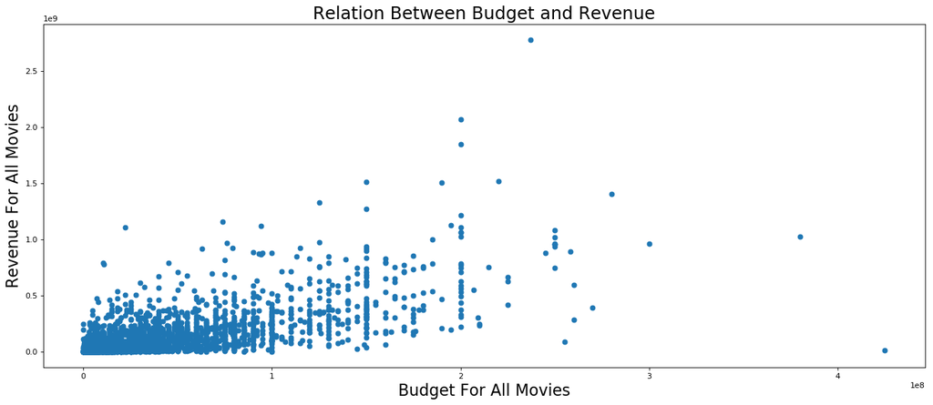

```python
plt.figure(figsize=(20, 8), dpi=80)
plt.scatter(x=df_new_data['budget'],y=df_new_data['revenue']);
plt.title("Relation Between Budget and Revenue", fontsize=22)
plt.xlabel('Budget For All Movies',fontsize=20)
plt.ylabel('Revenue For All Movies',fontsize=20)
```

### Question 9: Relation between release date and revenue ?

```
Text(0,0.5,'Revenue')
```

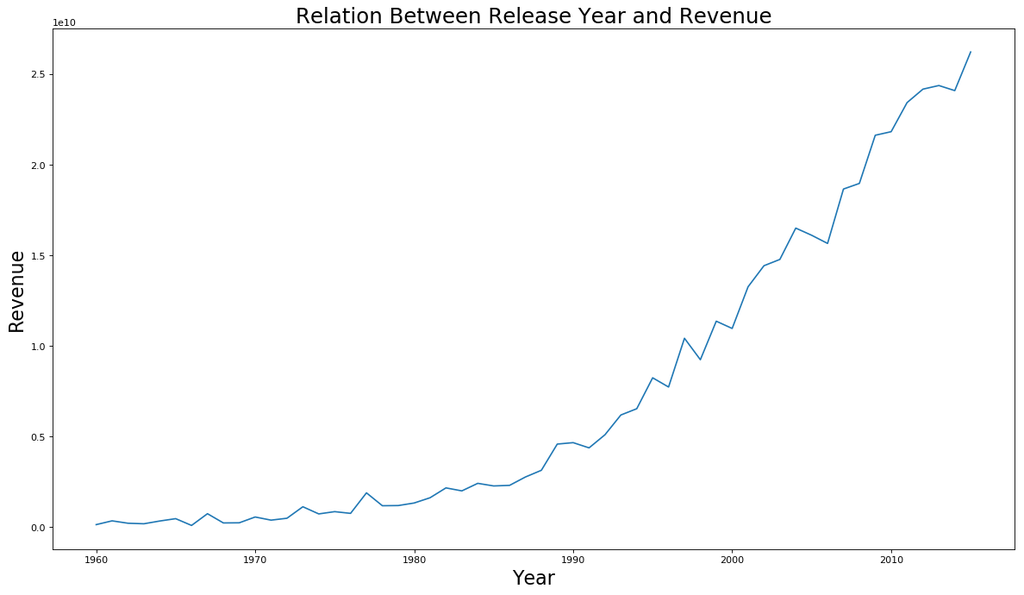

```python
years_and_revenue=df_new_data.groupby('release_year')['revenue'].sum()
plt.figure(figsize=(18, 10), dpi=80)
plt.plot(years_and_revenue);
plt.title("Relation Between Release Year and Revenue", fontsize=22)
plt.xlabel('Year',fontsize=20)
plt.ylabel('Revenue',fontsize=20)
```

### Question 10: What is sum of each genre in the data set ?

### Question 11: Relation between genre type and revenue ?

### Question 12: Relation between each genre type and popularity?

- Splitted function: To split the columns which contain data with | separated
- generate_conclusion function: To generate conclusion about thoes columns

```python
def splitted(column):
    # split the data in the column by | to be converted to list for better handling
    df_new_data[column]=df_new_data[column].apply(lambda x: x.split("|"))
def generate_conclusion(column):
    # We need dictionaries for :
    # 1- counts for each element of the data
    # 2- sum of the revenue for each element of the data
    # 3- sum of the popularity for each element of the data
    # 4- sum of the profit for each element of the data
    dictionary=dict()
    dictionary_revenue=dict()
    dictionary_popularity=dict()
    dictionary_profit=dict()
    # i is an index for the row to access the row by indexing
    i=0
    for a in df_new_data[column]:
        for b in a:
            # Here, We count of the data
            dictionary[b]=dictionary.get(b,0)+1
            # Here, We sum the revenue of each typeof data
            dictionary_revenue[b]=dictionary_revenue.get(b,0)+df_new_data['revenue'].iloc[i]
            # Here, We sum the popularity of each typeof data
            dictionary_popularity[b]=dictionary_popularity.get(b,0)+df_new_data['popularity'].iloc[i]
            # Here, We sum the profit of each typeof data
            dictionary_profit[b]=dictionary_profit.get(b,0)+df_new_data['profit'].iloc[i]
        # increment the i for the next row
        i=i+1
    # Generate a data frame for organizing our conclusion
    df=pd.DataFrame(dictionary,index=['counts'])
    df=df.append(pd.DataFrame(dictionary_revenue,index=['total_revenue']))
    df=df.append(pd.DataFrame(dictionary_popularity,index=['total_popularity']))
    df=df.append(pd.DataFrame(dictionary_profit,index=['total_profit']))
    # Transpose the data frame to better visualization
    df=df.T
    # Number of counts differs from  each type of data so, we calculated the mean for the revenue and profit and popularity
    df['mean_popularity']=df['total_popularity']/df['counts']
    df['mean_revenue']=df['total_revenue']/df['counts']
    df['mean_profit']=df['total_profit']/df['counts']
    return df
```

```python
splitted('genres')
df_new_data['genres']
```

```
0           [Action, Adventure, Science Fiction, Thriller]
1           [Action, Adventure, Science Fiction, Thriller]
2                   [Adventure, Science Fiction, Thriller]
3            [Action, Adventure, Science Fiction, Fantasy]
4                                [Action, Crime, Thriller]
5                    [Western, Drama, Adventure, Thriller]
6           [Science Fiction, Action, Thriller, Adventure]
7                      [Drama, Adventure, Science Fiction]
8                   [Family, Animation, Adventure, Comedy]
9                              [Comedy, Animation, Family]
10                              [Action, Adventure, Crime]
11           [Science Fiction, Fantasy, Action, Adventure]
12                                [Drama, Science Fiction]
13                       [Action, Comedy, Science Fiction]
14                    [Action, Adventure, Science Fiction]
```

[output cut: 47 more lines]

```python
df_genres=generate_conclusion('genres')
df_genres
```

|  | counts | total_revenue | total_popularity | total_profit | mean_popularity | mean_revenue | mean_profit |
| --- | --- | --- | --- | --- | --- | --- | --- |
| Action | 1085.0 | 1.698862e+11 | 1700.320953 | 1.086483e+11 | 1.567116 | 1.565772e+08 | 1.001367e+08 |
| Adventure | 749.0 | 1.635006e+11 | 1398.902084 | 1.111164e+11 | 1.867693 | 2.182919e+08 | 1.483529e+08 |
| Science Fiction | 519.0 | 8.508129e+10 | 972.239433 | 5.602414e+10 | 1.873294 | 1.639331e+08 | 1.079463e+08 |
| Thriller | 1203.0 | 1.176795e+11 | 1515.581815 | 7.277981e+10 | 1.259835 | 9.782170e+07 | 6.049859e+07 |
| Fantasy | 396.0 | 8.642072e+10 | 694.708555 | 5.841663e+10 | 1.754315 | 2.182341e+08 | 1.475167e+08 |
| Crime | 651.0 | 5.477715e+10 | 731.698494 | 3.327089e+10 | 1.123961 | 8.414309e+07 | 5.110735e+07 |
| Western | 52.0 | 4.545472e+09 | 58.980777 | 1.798058e+09 | 1.134246 | 8.741292e+07 | 3.457804e+07 |
| Drama | 1753.0 | 1.305071e+11 | 1757.967731 | 8.125677e+10 | 1.002834 | 7.444785e+07 | 4.635298e+07 |
| Family | 425.0 | 8.634026e+10 | 620.093449 | 5.978662e+10 | 1.459043 | 2.031535e+08 | 1.406744e+08 |
| Animation | 201.0 | 5.168142e+10 | 343.835008 | 3.621719e+10 | 1.710622 | 2.571215e+08 | 1.801850e+08 |
| Comedy | 1357.0 | 1.321721e+11 | 1374.583912 | 8.721414e+10 | 1.012958 | 9.740019e+07 | 6.426981e+07 |
| Mystery | 344.0 | 3.131975e+10 | 393.058731 | 1.925782e+10 | 1.142613 | 9.104578e+07 | 5.598205e+07 |
| Romance | 666.0 | 5.718292e+10 | 636.763571 | 3.899445e+10 | 0.956101 | 8.586024e+07 | 5.855023e+07 |
| War | 119.0 | 1.261782e+10 | 148.289378 | 7.589371e+09 | 1.246129 | 1.060321e+08 | 6.377623e+07 |
| History | 129.0 | 1.050128e+10 | 125.216909 | 5.250303e+09 | 0.970674 | 8.140524e+07 | 4.070002e+07 |
| Music | 134.0 | 1.124219e+10 | 121.902162 | 7.741329e+09 | 0.909718 | 8.389694e+07 | 5.777111e+07 |
| Horror | 463.0 | 2.652425e+10 | 395.404211 | 1.792805e+10 | 0.854005 | 5.728780e+07 | 3.872150e+07 |
| Documentary | 31.0 | 7.543454e+08 | 9.802957 | 5.924973e+08 | 0.316224 | 2.433372e+07 | 1.911282e+07 |
| Foreign | 12.0 | 1.335074e+08 | 2.187251 | 1.508876e+07 | 0.182271 | 1.112562e+07 | 1.257396e+06 |
| TV Movie | 1.0 | 4.200000e+07 | 0.273628 | 3.700000e+07 | 0.273628 | 4.200000e+07 | 3.700000e+07 |

Convert index rows to columns to use at seaborn library

```python
df_genres['genres']=df_genres.index
df_genres
```

|  | counts | total_revenue | total_popularity | total_profit | mean_popularity | mean_revenue | mean_profit | genres |
| --- | --- | --- | --- | --- | --- | --- | --- | --- |
| Action | 1085.0 | 1.698862e+11 | 1700.320953 | 1.086483e+11 | 1.567116 | 1.565772e+08 | 1.001367e+08 | Action |
| Adventure | 749.0 | 1.635006e+11 | 1398.902084 | 1.111164e+11 | 1.867693 | 2.182919e+08 | 1.483529e+08 | Adventure |
| Science Fiction | 519.0 | 8.508129e+10 | 972.239433 | 5.602414e+10 | 1.873294 | 1.639331e+08 | 1.079463e+08 | Science Fiction |
| Thriller | 1203.0 | 1.176795e+11 | 1515.581815 | 7.277981e+10 | 1.259835 | 9.782170e+07 | 6.049859e+07 | Thriller |
| Fantasy | 396.0 | 8.642072e+10 | 694.708555 | 5.841663e+10 | 1.754315 | 2.182341e+08 | 1.475167e+08 | Fantasy |
| Crime | 651.0 | 5.477715e+10 | 731.698494 | 3.327089e+10 | 1.123961 | 8.414309e+07 | 5.110735e+07 | Crime |
| Western | 52.0 | 4.545472e+09 | 58.980777 | 1.798058e+09 | 1.134246 | 8.741292e+07 | 3.457804e+07 | Western |
| Drama | 1753.0 | 1.305071e+11 | 1757.967731 | 8.125677e+10 | 1.002834 | 7.444785e+07 | 4.635298e+07 | Drama |
| Family | 425.0 | 8.634026e+10 | 620.093449 | 5.978662e+10 | 1.459043 | 2.031535e+08 | 1.406744e+08 | Family |
| Animation | 201.0 | 5.168142e+10 | 343.835008 | 3.621719e+10 | 1.710622 | 2.571215e+08 | 1.801850e+08 | Animation |
| Comedy | 1357.0 | 1.321721e+11 | 1374.583912 | 8.721414e+10 | 1.012958 | 9.740019e+07 | 6.426981e+07 | Comedy |
| Mystery | 344.0 | 3.131975e+10 | 393.058731 | 1.925782e+10 | 1.142613 | 9.104578e+07 | 5.598205e+07 | Mystery |
| Romance | 666.0 | 5.718292e+10 | 636.763571 | 3.899445e+10 | 0.956101 | 8.586024e+07 | 5.855023e+07 | Romance |
| War | 119.0 | 1.261782e+10 | 148.289378 | 7.589371e+09 | 1.246129 | 1.060321e+08 | 6.377623e+07 | War |
| History | 129.0 | 1.050128e+10 | 125.216909 | 5.250303e+09 | 0.970674 | 8.140524e+07 | 4.070002e+07 | History |
| Music | 134.0 | 1.124219e+10 | 121.902162 | 7.741329e+09 | 0.909718 | 8.389694e+07 | 5.777111e+07 | Music |
| Horror | 463.0 | 2.652425e+10 | 395.404211 | 1.792805e+10 | 0.854005 | 5.728780e+07 | 3.872150e+07 | Horror |
| Documentary | 31.0 | 7.543454e+08 | 9.802957 | 5.924973e+08 | 0.316224 | 2.433372e+07 | 1.911282e+07 | Documentary |
| Foreign | 12.0 | 1.335074e+08 | 2.187251 | 1.508876e+07 | 0.182271 | 1.112562e+07 | 1.257396e+06 | Foreign |
| TV Movie | 1.0 | 4.200000e+07 | 0.273628 | 3.700000e+07 | 0.273628 | 4.200000e+07 | 3.700000e+07 | TV Movie |

```
Text(0,0.5,'Counts of Genres')
```

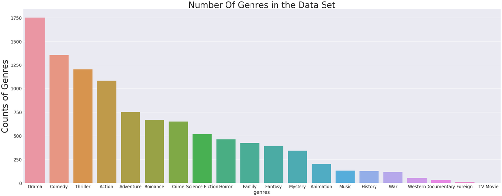

```python
plt.figure(figsize=(40, 15), dpi=80)
sns.barplot(x='genres',
            y='counts',
            data=df_genres,
            order=df_genres.sort_values('counts',ascending = False).genres);
plt.title("Number Of Genres in the Data Set", fontsize=40)
plt.ylabel('Counts of Genres',fontsize=40)
```

### To get which genres are mentinoed the most

```python
# Here, we get the mean of the counts column
mean_number_genres=df_genres.counts.mean()
# choose only the genres that greater than the mean to be the most mentioned genres
df_genres[df_genres.counts > mean_number_genres]
```

|  | counts | total_revenue | total_popularity | total_profit | mean_popularity | mean_revenue | mean_profit | genres |
| --- | --- | --- | --- | --- | --- | --- | --- | --- |
| Action | 1085.0 | 1.698862e+11 | 1700.320953 | 1.086483e+11 | 1.567116 | 1.565772e+08 | 1.001367e+08 | Action |
| Adventure | 749.0 | 1.635006e+11 | 1398.902084 | 1.111164e+11 | 1.867693 | 2.182919e+08 | 1.483529e+08 | Adventure |
| Science Fiction | 519.0 | 8.508129e+10 | 972.239433 | 5.602414e+10 | 1.873294 | 1.639331e+08 | 1.079463e+08 | Science Fiction |
| Thriller | 1203.0 | 1.176795e+11 | 1515.581815 | 7.277981e+10 | 1.259835 | 9.782170e+07 | 6.049859e+07 | Thriller |
| Crime | 651.0 | 5.477715e+10 | 731.698494 | 3.327089e+10 | 1.123961 | 8.414309e+07 | 5.110735e+07 | Crime |
| Drama | 1753.0 | 1.305071e+11 | 1757.967731 | 8.125677e+10 | 1.002834 | 7.444785e+07 | 4.635298e+07 | Drama |
| Comedy | 1357.0 | 1.321721e+11 | 1374.583912 | 8.721414e+10 | 1.012958 | 9.740019e+07 | 6.426981e+07 | Comedy |
| Romance | 666.0 | 5.718292e+10 | 636.763571 | 3.899445e+10 | 0.956101 | 8.586024e+07 | 5.855023e+07 | Romance |

```
Text(0.5,1,'Relation Between Genre Type and Revenue')
```

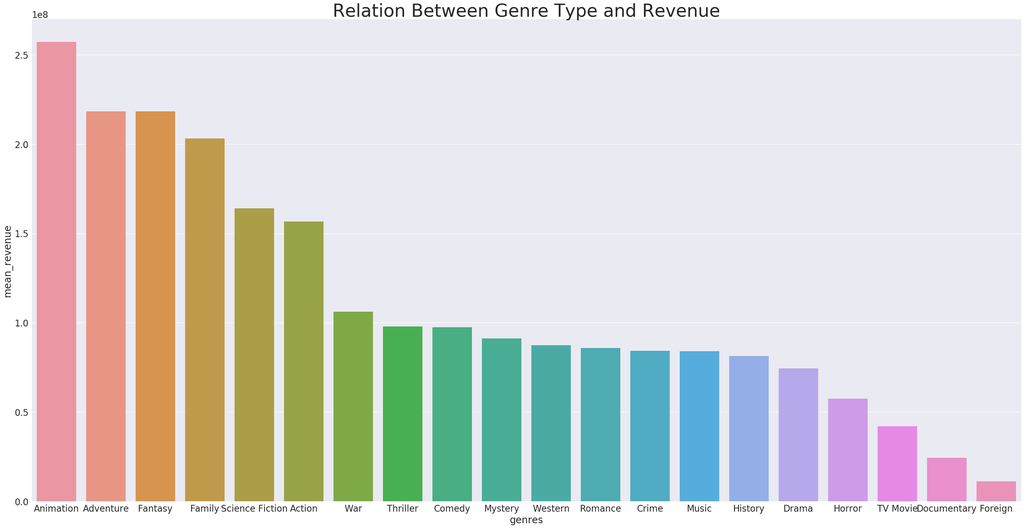

```python
plt.figure(figsize=(40, 20), dpi=80)
sns.barplot(x='genres',
            y="mean_revenue", data=df_genres,
            order=df_genres.sort_values('mean_revenue',ascending = False).genres);
plt.title("Relation Between Genre Type and Revenue", fontsize=40)
```

```python
# Here, we get the mean of the mean_revenue column
mean_revenue_genres=df_genres.mean_revenue.mean()
# choose only the genres that greater than the mean revenue to be the most genres with high revenue
df_genres[df_genres.mean_revenue > mean_revenue_genres]
```

|  | counts | total_revenue | total_popularity | total_profit | mean_popularity | mean_revenue | mean_profit | genres |
| --- | --- | --- | --- | --- | --- | --- | --- | --- |
| Action | 1085.0 | 1.698862e+11 | 1700.320953 | 1.086483e+11 | 1.567116 | 1.565772e+08 | 1.001367e+08 | Action |
| Adventure | 749.0 | 1.635006e+11 | 1398.902084 | 1.111164e+11 | 1.867693 | 2.182919e+08 | 1.483529e+08 | Adventure |
| Science Fiction | 519.0 | 8.508129e+10 | 972.239433 | 5.602414e+10 | 1.873294 | 1.639331e+08 | 1.079463e+08 | Science Fiction |
| Fantasy | 396.0 | 8.642072e+10 | 694.708555 | 5.841663e+10 | 1.754315 | 2.182341e+08 | 1.475167e+08 | Fantasy |
| Family | 425.0 | 8.634026e+10 | 620.093449 | 5.978662e+10 | 1.459043 | 2.031535e+08 | 1.406744e+08 | Family |
| Animation | 201.0 | 5.168142e+10 | 343.835008 | 3.621719e+10 | 1.710622 | 2.571215e+08 | 1.801850e+08 | Animation |

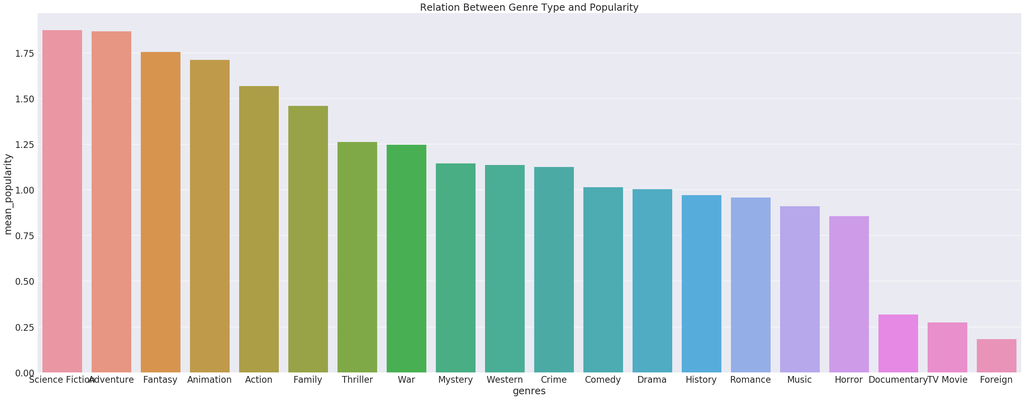

```python
plt.figure(figsize=(40, 15), dpi=80)
plt.title("Relation Between Genre Type and Popularity", fontsize=22)
sns.barplot(x='genres',
            y="mean_popularity", data=df_genres,
            order=df_genres.sort_values('mean_popularity',ascending = False).genres);
```

```python
# Here, we get the mean of the mean_popularity column
mean_popularity_genres=df_genres.mean_popularity.mean()
# choose only the genres that greater than the mean popularity to be the most genres with high popularity
df_genres[df_genres.mean_popularity > mean_popularity_genres]
```

|  | counts | total_revenue | total_popularity | total_profit | mean_popularity | mean_revenue | mean_profit | genres |
| --- | --- | --- | --- | --- | --- | --- | --- | --- |
| Action | 1085.0 | 1.698862e+11 | 1700.320953 | 1.086483e+11 | 1.567116 | 1.565772e+08 | 1.001367e+08 | Action |
| Adventure | 749.0 | 1.635006e+11 | 1398.902084 | 1.111164e+11 | 1.867693 | 2.182919e+08 | 1.483529e+08 | Adventure |
| Science Fiction | 519.0 | 8.508129e+10 | 972.239433 | 5.602414e+10 | 1.873294 | 1.639331e+08 | 1.079463e+08 | Science Fiction |
| Thriller | 1203.0 | 1.176795e+11 | 1515.581815 | 7.277981e+10 | 1.259835 | 9.782170e+07 | 6.049859e+07 | Thriller |
| Fantasy | 396.0 | 8.642072e+10 | 694.708555 | 5.841663e+10 | 1.754315 | 2.182341e+08 | 1.475167e+08 | Fantasy |
| Western | 52.0 | 4.545472e+09 | 58.980777 | 1.798058e+09 | 1.134246 | 8.741292e+07 | 3.457804e+07 | Western |
| Family | 425.0 | 8.634026e+10 | 620.093449 | 5.978662e+10 | 1.459043 | 2.031535e+08 | 1.406744e+08 | Family |
| Animation | 201.0 | 5.168142e+10 | 343.835008 | 3.621719e+10 | 1.710622 | 2.571215e+08 | 1.801850e+08 | Animation |
| Mystery | 344.0 | 3.131975e+10 | 393.058731 | 1.925782e+10 | 1.142613 | 9.104578e+07 | 5.598205e+07 | Mystery |
| War | 119.0 | 1.261782e+10 | 148.289378 | 7.589371e+09 | 1.246129 | 1.060321e+08 | 6.377623e+07 | War |

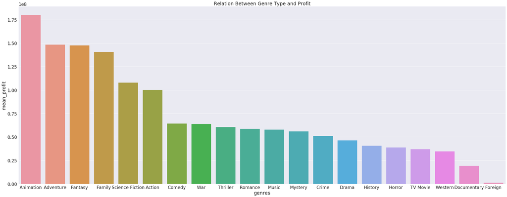

```python
plt.figure(figsize=(40, 15), dpi=80)
plt.title("Relation Between Genre Type and Profit", fontsize=22)
sns.barplot(x='genres',
            y="mean_profit", data=df_genres,
            order=df_genres.sort_values('mean_profit',ascending = False).genres);
```

```python
# Here, we get the mean of the mean_profit column
mean_profit_genres=df_genres.mean_profit.mean()
# choose only the genres that greater than the mean profit to be the most genres with high profit
df_genres[df_genres.mean_profit > mean_profit_genres]
```

|  | counts | total_revenue | total_popularity | total_profit | mean_popularity | mean_revenue | mean_profit | genres |
| --- | --- | --- | --- | --- | --- | --- | --- | --- |
| Action | 1085.0 | 1.698862e+11 | 1700.320953 | 1.086483e+11 | 1.567116 | 1.565772e+08 | 1.001367e+08 | Action |
| Adventure | 749.0 | 1.635006e+11 | 1398.902084 | 1.111164e+11 | 1.867693 | 2.182919e+08 | 1.483529e+08 | Adventure |
| Science Fiction | 519.0 | 8.508129e+10 | 972.239433 | 5.602414e+10 | 1.873294 | 1.639331e+08 | 1.079463e+08 | Science Fiction |
| Fantasy | 396.0 | 8.642072e+10 | 694.708555 | 5.841663e+10 | 1.754315 | 2.182341e+08 | 1.475167e+08 | Fantasy |
| Family | 425.0 | 8.634026e+10 | 620.093449 | 5.978662e+10 | 1.459043 | 2.031535e+08 | 1.406744e+08 | Family |
| Animation | 201.0 | 5.168142e+10 | 343.835008 | 3.621719e+10 | 1.710622 | 2.571215e+08 | 1.801850e+08 | Animation |